# Unequal Development of Brazil Municipalities

# Abstract

This exploratory data analysis project aims to determine factors affecting the unequal development of Brazil at the municipality level.

The relationship between explanatory variables and GDP per capita is modelled by a multi-linear regression model, where some variables undergo transformation to better fit the model. To account for spatial autocorrelation between municipalities, Geographically Weighted Regression is adopted in formulating the linear model.

We find that the coefficient estimates for the explanatory variables remain statistically significant even in local linear models.

We observe a variation in residuals between municipalities of different sizes. The actual values of GDP per capita in large areas are more than the predicted values and the actual values of GDP per capita in small areas fall below the predicted values.

**In this project, we will utilize the data analysis tools and representations:**

1. Correlation Plots of all variables
2. Histogram Plots of explanatory variables
3. Multi-Linear Regression Model (Global and Local - Geographically Weighted Regression)
4. Assumption Testing for the Linear Regression Models
5. Choropleth Maps of GDP per capita, residuals and standard errors

# Acknowledgements

The data used was gathered by Professor Kam Tin Seong for academic purposes. They can be obtained [here](https://github.com/reginaooi/Brazil_Municipalities/tree/main/data)

```r
packages = c('olsrr', 'corrplot', 'ggpubr', 'sf', 'spdep', 'GWmodel', 'tmap', 'tidyverse', 'geobr', 'fastDummies', 'EnvStats', 'rmdformats', 'DT')
for (p in packages){
  if(!require(p, character.only = T)){
    install.packages(p)
  }
  library(p,character.only = T)
}
```

# Data

## Aspatial Data Import

We will be importing this data file containing the information for cities in Brazil.

```r
brazilcities <- readr::read_csv2("data/aspatial/BRAZIL_CITIES.csv")

brazilcities %>%
  slice(1:10) %>%
  datatable()
```

|  | CITY | STATE | CAPITAL | IBGE_RES_POP | IBGE_RES_POP_BRAS | IBGE_RES_POP_ESTR | IBGE_DU | IBGE_DU_URBAN | IBGE_DU_RURAL | IBGE_POP | IBGE_1 | IBGE_1-4 | IBGE_5-9 | IBGE_10-14 | IBGE_15-59 | IBGE_60+ | IBGE_PLANTED_AREA | IBGE_CROP_PRODUCTION_$ | IDHM Ranking 2010 | IDHM | IDHM_Renda | IDHM_Longevidade | IDHM_Educacao | LONG | LAT | ALT | PAY_TV | FIXED_PHONES | AREA | … |
| --- | --- | --- | --- | --- | --- | --- | --- | --- | --- | --- | --- | --- | --- | --- | --- | --- | --- | --- | --- | --- | --- | --- | --- | --- | --- | --- | --- | --- | --- | --- |
| 1 | Abadia De Goiás | GO | 0 | 6876 | 6876 | 0 | 2137 | 1546 | 591 | 5300 | 69 | 318 | 438 | 517 | 3542 | 416 | 319 | 1843 | 1689 | 0.708 | 0.687 | 0.83 | 0.622 | -4944054783 | -1675881189 | 893.6 | 360 | 842 | 14726 | … |
| 2 | Abadia Dos Dourados | MG | 0 | 6704 | 6704 | 0 | 2328 | 1481 | 847 | 4154 | 38 | 207 | 260 | 351 | 2709 | 589 | 4479 | 18017 | 2207 | 0.69 | 0.693 | 0.839 | 0.563 | -4739683244 | -1848756496 | 753.12 | 77 | 296 | 88106 | … |
| 3 | Abadiânia | GO | 0 | 15757 | 15609 | 148 | 4655 | 3233 | 1422 | 10656 | 139 | 650 | 894 | 1087 | 6896 | 990 | 10307 | 33085 | 2202 | 0.69 | 0.671 | 0.841 | 0.579 | -4871881214 | -1618267186 | 1017.55 | 227 | 720 | 1.04513 | … |
| 4 | Abaeté | MG | 0 | 22690 | 22690 | 0 | 7694 | 6667 | 1027 | 18464 | 176 | 856 | 1233 | 1539 | 11979 | 2681 | 1862 | 7502 | 1994 | 0.698 | 0.72 | 0.848 | 0.556 | -4544619142 | -1915584769 | 644.74 | 1230 | 1716 | 1.81707 | … |
| 5 | Abaetetuba | PA | 0 | 141100 | 141040 | 60 | 31061 | 19057 | 12004 | 82956 | 1354 | 5567 | 7618 | 8905 | 53516 | 5996 | 25200 | 700872 | 3530 | 0.628 | 0.579 | 0.798 | 0.537 | -4888440382 | -1723469863 | 10.12 | 3389 | 1218 | 1.61065 | … |
| 6 | Abaiara | CE | 0 | 10496 | 10496 | 0 | 2791 | 1251 | 1540 | 4538 | 98 | 323 | 421 | 483 | 2631 | 582 | 2598 | 5234 | 3522 | 0.628 | 0.54 | 0.748 | 0.612 | -3904754664 | -7356976596 | 403.11 | 29 | 34 | 18008 | … |
| 7 | Abaíra | BA | 0 | 8316 | 8316 | 0 | 2572 | 1193 | 1379 | 3725 | 37 | 156 | 263 | 277 | 2319 | 673 | 895 | 3999 | 4086 | 0.603 | 0.577 | 0.746 | 0.51 | -4166160848 | -1325353189 | 674.22 | 952 | 335 | 53868 | … |
| 8 | Abaré | BA | 0 | 17064 | 17064 | 0 | 4332 | 2379 | 1953 | 8994 | 167 | 733 | 978 | 927 | 5386 | 803 | 2058 | 22761 | 4756 | 0.575 | 0.533 | 0.776 | 0.46 | -3911658794 | -8723418246 | 316.38 | 51 | 222 | 1.60492 | … |
| 9 | Abatiá | PR | 0 | 7764 | 7764 | 0 | 2499 | 1877 | 622 | 5685 | 69 | 302 | 370 | 483 | 3650 | 811 | 1197 | 9943 | 2258 | 0.687 | 0.676 | 0.804 | 0.596 | -5031252658 | -2330049404 | 579.3 | 55 | 392 | 22872 | … |
| 10 | Abdon Batista | SC | 0 | 2653 | 2653 | 0 | 848 | 234 | 614 | 724 | 12 | 32 | 49 | 63 | 479 | 89 | 5502 | 26195 | 2092 | 0.69 | 0.66 | 0.812 | 0.625 | -5102527221 | -2760898712 | 720.98 | 109 | 260 | 23716 | … |

```r
# This data dictionary will allow us to understand the units of the variables in brazilcities
datadict <- readr::read_csv2("data/aspatial/Data_Dictionary.csv")
datadict <- slice(datadict, 1:81)
datadict %>%
  slice(1:10) %>%
  datatable()
```

|  | FIELD | DESCRIPTION | REFERENCE | UNIT | SOURCE | X6 |
| --- | --- | --- | --- | --- | --- | --- |
| 1 | CITY | Name of the City |  |  | - |  |
| 2 | STATE | Name of the State |  |  | - |  |
| 3 | CAPITAL | 1 if Capital of State |  |  | - |  |
| 4 | IBGE_RES_POP | Resident Population | 2010 | - | https://sidra.ibge.gov.br/tabela/1497 |  |
| 5 | IBGE_RES_POP_BRAS | Resident Population Brazilian | 2010 | - | https://sidra.ibge.gov.br/tabela/1497 |  |
| 6 | IBGE_RES_POP_ESTR | Redident Population Foreigners | 2010 | - | https://sidra.ibge.gov.br/tabela/1497 |  |
| 7 | IBGE_DU | Domestic Units Total | 2010 | - | https://sidra.ibge.gov.br/tabela/3495 |  |
| 8 | IBGE_DU_URBAN | Domestic Units Urban | 2010 | - | https://sidra.ibge.gov.br/tabela/3495 |  |
| 9 | IBGE_DU_RURAL | Domestic Units Rural | 2010 | - | https://sidra.ibge.gov.br/tabela/3495 |  |
| 10 | IBGE_POP | Resident Population Regular Urban Planning | 2010 | - | https://sidra.ibge.gov.br/tabela/3365 |  |

## Geospatial Data Import

We will be importing this data file containing the geospatial information for cities in Brazil.

```r
municipalities <- st_read(dsn = "data/muni_sf", layer = "muni_sf")
# Checking the coordinate reference system for municipalities
st_crs(municipalities)
```

```
## Coordinate Reference System:
##   No user input
##   wkt:
## GEOGCS["GCS_SIRGAS_2000",
##     DATUM["Sistema_de_Referencia_Geocentrico_para_las_AmericaS_2000",
##         SPHEROID["GRS_1980",6378137.0,298.257222101]],
##     PRIMEM["Greenwich",0.0],
##     UNIT["Degree",0.0174532925199433]]
```

```r
# Checking for NA and duplicate values
any(is.na(brazilcities))
```

```
## [1] TRUE
```

```r
any(duplicated(brazilcities))
```

```
## [1] FALSE
```

```r
brazilcities[rowSums(is.na(brazilcities))!=0,]
```

```
## # A tibble: 5,538 x 81
##    CITY  STATE CAPITAL IBGE_RES_POP IBGE_RES_POP_BR~ IBGE_RES_POP_ES~
##    <chr> <chr>   <dbl>        <dbl>            <dbl>            <dbl>
##  1 Abad~ GO          0         6876             6876                0
##  2 Abad~ MG          0         6704             6704                0
##  3 Abad~ GO          0        15757            15609              148
##  4 Abae~ MG          0        22690            22690                0
##  5 Abae~ PA          0       141100           141040               60
##  6 Abai~ CE          0        10496            10496                0
##  7 Abaí~ BA          0         8316             8316                0
##  8 Abaré BA          0        17064            17064                0
##  9 Abat~ PR          0         7764             7764                0
## 10 Abdo~ SC          0         2653             2653                0
## # ... with 5,528 more rows, and 75 more variables: IBGE_DU <dbl>,
## #   IBGE_DU_URBAN <dbl>, IBGE_DU_RURAL <dbl>, IBGE_POP <dbl>,
## #   IBGE_1 <dbl>, `IBGE_1-4` <dbl>, `IBGE_5-9` <dbl>, `IBGE_10-14` <dbl>,
## #   `IBGE_15-59` <dbl>, `IBGE_60+` <dbl>, IBGE_PLANTED_AREA <dbl>,
## #   `IBGE_CROP_PRODUCTION_$` <dbl>, `IDHM Ranking 2010` <dbl>, IDHM <chr>,
## #   IDHM_Renda <chr>, IDHM_Longevidade <chr>, IDHM_Educacao <chr>,
## #   LONG <dbl>, LAT <dbl>, ALT <chr>, PAY_TV <dbl>, FIXED_PHONES <dbl>,
## #   AREA <dbl>, REGIAO_TUR <chr>, CATEGORIA_TUR <chr>,
## #   ESTIMATED_POP <dbl>, RURAL_URBAN <chr>, GVA_AGROPEC <chr>,
## #   GVA_INDUSTRY <chr>, GVA_SERVICES <dbl>, GVA_PUBLIC <dbl>,
## #   GVA_TOTAL <dbl>, TAXES <chr>, GDP <dbl>, POP_GDP <dbl>,
## #   GDP_CAPITA <dbl>, GVA_MAIN <chr>, MUN_EXPENDIT <dbl>, COMP_TOT <dbl>,
## #   COMP_A <dbl>, COMP_B <dbl>, COMP_C <dbl>, COMP_D <dbl>, COMP_E <dbl>,
## #   COMP_F <dbl>, COMP_G <dbl>, COMP_H <dbl>, COMP_I <dbl>, COMP_J <dbl>,
## #   COMP_K <dbl>, COMP_L <dbl>, COMP_M <dbl>, COMP_N <dbl>, COMP_O <dbl>,
## #   COMP_P <dbl>, COMP_Q <dbl>, COMP_R <dbl>, COMP_S <dbl>, COMP_T <dbl>,
## #   COMP_U <dbl>, HOTELS <dbl>, BEDS <dbl>, Pr_Agencies <dbl>,
## #   Pu_Agencies <dbl>, Pr_Bank <dbl>, Pu_Bank <dbl>, Pr_Assets <dbl>,
## #   Pu_Assets <dbl>, Cars <dbl>, Motorcycles <dbl>, Wheeled_tractor <dbl>,
## #   UBER <dbl>, MAC <dbl>, `WAL-MART` <dbl>, `POST_OFFICES,,,,` <chr>
```

```r
# Checking through the data types
summary(brazilcities)
```

```
##      CITY              STATE              CAPITAL
##  Length:5572        Length:5572        Min.   :0.000000
##  Class :character   Class :character   1st Qu.:0.000000
##  Mode  :character   Mode  :character   Median :0.000000
##                                        Mean   :0.004846
##                                        3rd Qu.:0.000000
##                                        Max.   :1.000000
##
##   IBGE_RES_POP      IBGE_RES_POP_BRAS  IBGE_RES_POP_ESTR
##  Min.   :     805   Min.   :     805   Min.   :     0.0
##  1st Qu.:    5235   1st Qu.:    5230   1st Qu.:     0.0
##  Median :   10934   Median :   10926   Median :     0.0
##  Mean   :   34278   Mean   :   34200   Mean   :    77.5
##  3rd Qu.:   23424   3rd Qu.:   23390   3rd Qu.:    10.0
##  Max.   :11253503   Max.   :11133776   Max.   :119727.0
##  NA's   :7          NA's   :7          NA's   :7
##     IBGE_DU        IBGE_DU_URBAN     IBGE_DU_RURAL      IBGE_POP
##  Min.   :    239   Min.   :     60   Min.   :    3   Min.   :     174
##  1st Qu.:   1572   1st Qu.:    874   1st Qu.:  487   1st Qu.:    2801
##  Median :   3174   Median :   1846   Median :  931   Median :    6170
##  Mean   :  10303   Mean   :   8859   Mean   : 1463   Mean   :   27595
##  3rd Qu.:   6726   3rd Qu.:   4624   3rd Qu.: 1832   3rd Qu.:   15302
##  Max.   :3576148   Max.   :3548433   Max.   :33809   Max.   :10463636
##  NA's   :9         NA's   :9         NA's   :80      NA's   :7
##      IBGE_1            IBGE_1-4         IBGE_5-9        IBGE_10-14
##  Min.   :     0.0   Min.   :     5   Min.   :     7   Min.   :    12
##  1st Qu.:    38.0   1st Qu.:   158   1st Qu.:   220   1st Qu.:   259
##  Median :    92.0   Median :   376   Median :   516   Median :   588
##  Mean   :   383.3   Mean   :  1544   Mean   :  2069   Mean   :  2381
##  3rd Qu.:   232.0   3rd Qu.:   951   3rd Qu.:  1300   3rd Qu.:  1478
##  Max.   :129464.0   Max.   :514794   Max.   :684443   Max.   :783702
##  NA's   :7          NA's   :7        NA's   :7        NA's   :7
##    IBGE_15-59         IBGE_60+       IBGE_PLANTED_AREA
##  Min.   :     94   Min.   :     29   Min.   :      0.0
##  1st Qu.:   1734   1st Qu.:    341   1st Qu.:    910.2
##  Median :   3841   Median :    722   Median :   3471.5
##  Mean   :  18212   Mean   :   3004   Mean   :  14179.9
##  3rd Qu.:   9628   3rd Qu.:   1724   3rd Qu.:  11194.2
##  Max.   :7058221   Max.   :1293012   Max.   :1205669.0
##  NA's   :7         NA's   :7         NA's   :2
```

[output cut: 137 more lines]

```
##  Min.   :      4   Min.   :   0.000   Min.   :1      Min.   :  1.000
##  1st Qu.:    591   1st Qu.:   0.000   1st Qu.:1      1st Qu.:  1.000
##  Median :   1285   Median :   0.000   Median :1      Median :  2.000
##  Mean   :   4879   Mean   :   5.755   Mean   :1      Mean   :  4.277
##  3rd Qu.:   3295   3rd Qu.:   1.000   3rd Qu.:1      3rd Qu.:  3.000
##  Max.   :1134570   Max.   :3236.000   Max.   :1      Max.   :130.000
##  NA's   :11        NA's   :11         NA's   :5447   NA's   :5406
##     WAL-MART      POST_OFFICES,,,,
##  Min.   : 1.000   Length:5572
##  1st Qu.: 1.000   Class :character
##  Median : 1.000   Mode  :character
##  Mean   : 2.059
##  3rd Qu.: 1.750
##  Max.   :26.000
##  NA's   :5470
```

```r
brazilcities$IDHM_Educacao  <- as.numeric(brazilcities$IDHM_Educacao)
brazilcities$IDHM_Longevidade <- as.numeric(brazilcities$IDHM_Longevidade)
brazilcities$TAXES <- as.numeric(brazilcities$TAXES)
brazilcities$GVA_AGROPEC <- as.numeric(brazilcities$GVA_AGROPEC)
brazilcities$GVA_INDUSTRY  <- as.numeric(brazilcities$GVA_INDUSTRY)
brazilcities$IDHM  <- as.numeric(brazilcities$IDHM)
brazilcities$ALT  <- as.numeric(brazilcities$ALT)
brazilcities$IDHM_Renda <- as.numeric(brazilcities$IDHM_Renda)
```

**Selecting variables**

Variables such as PU_Assets (Total amount of public bank assets) and MACS (Number of Mcdonalds) have NA values for many of the municipalities. With the NA values, it is difficult to make comparisons across municipalities to determine if they contribute to variations in GDP, so we will be removing them.

Here, we will be extracting the necessary columns using select() from *dplyr* in *tidyverse* and creating binary columns from RURAL_URBAN using dummy_cols() from *fastDummies*.

```r
brazilcities_GDP <- brazilcities %>%
 dplyr::select("CITY", "STATE", "CAPITAL", "LONG", "LAT", "GDP_CAPITA", "IBGE_15-59", "IDHM_Educacao", "IDHM_Longevidade", "IDHM_Renda", "AREA", "TAXES", "COMP_TOT", "RURAL_URBAN", "IBGE_RES_POP", "IBGE_POP", "IBGE_DU_URBAN", "IBGE_DU_RURAL", "IBGE_DU", "IBGE_PLANTED_AREA", "GVA_AGROPEC", "GVA_INDUSTRY", "GVA_SERVICES", "GVA_PUBLIC", "POP_GDP", "Cars", "Motorcycles", "PAY_TV", "FIXED_PHONES", "IBGE_RES_POP_BRAS") %>%
  dummy_cols(select_columns = "RURAL_URBAN") %>%
  dplyr::mutate(`working_prop` = `IBGE_15-59`/`IBGE_POP`) %>%
  mutate(`local_prop` = `IBGE_RES_POP_BRAS`/`IBGE_RES_POP`) %>%
  mutate(`du_urban_prop` = `IBGE_DU_URBAN`/`IBGE_DU`) %>%
  mutate(`pop_density` = `POP_GDP`/`AREA`) %>%
  mutate(`planted_prop` = `IBGE_PLANTED_AREA`/`AREA`) %>%
  mutate(`avg_tax` = `TAXES`/`IBGE_POP`) %>%
  mutate(`agropec_percap` = `GVA_AGROPEC`/`POP_GDP`) %>%
  mutate(`industry_percap` = `GVA_INDUSTRY`/`POP_GDP`) %>%
  mutate(`services_percap` = `GVA_SERVICES`/`POP_GDP`) %>%
  mutate(`public_percap` = `GVA_PUBLIC`/`POP_GDP`) %>%
  mutate(`paytv_prop` = `PAY_TV`/`IBGE_POP`) %>%
  mutate(`phones_prop` = `FIXED_PHONES`/`IBGE_POP`) %>%
  mutate(`longitude` = (`LONG`/100000000)) %>%
  mutate(`latitude` = (`LAT`/100000000)) %>%
  rename("city" = "CITY", "state" = "STATE", "gdp_capita" = "GDP_CAPITA", "edu_hdi" = "IDHM_Educacao", "life_hdi" = "IDHM_Longevidade","gni_hdi" = "IDHM_Renda", "area" = "AREA", "intermediate_adjacent" = "RURAL_URBAN_Intermediário Adjacente", "intermediate_remote" = "RURAL_URBAN_Intermediário Remoto", "rural_adjacent" = "RURAL_URBAN_Rural Adjacente", "rural_remote" = "RURAL_URBAN_Rural Remoto", "urban" = "RURAL_URBAN_Urbano") %>%
  dplyr::select(-"RURAL_URBAN", -"RURAL_URBAN_NA", -"IBGE_15-59", -"IBGE_RES_POP", -"RURAL_URBAN_Sem classificação", -"IBGE_DU_URBAN", - "IBGE_DU", -"IBGE_DU_RURAL", -"TAXES", -"COMP_TOT", -"POP_GDP", -"IBGE_PLANTED_AREA", -"LONG", -"LAT", -"PAY_TV", -"FIXED_PHONES", -"IBGE_RES_POP_BRAS", -"IBGE_POP",  -"GVA_AGROPEC", -"GVA_INDUSTRY", - "GVA_SERVICES", -"GVA_PUBLIC")
```

We will keep the observations with NA values for now, but we will create a copy with the NA values removed, so we can do a correlation plot later on.

```r
brazilcities_GDP_rm <- na.omit(brazilcities_GDP)
```

Projecting brazilcities_edited in the same projection system as municipalities, so that we can create a statistical point map later on.

```r
brazilcities.sf <- st_as_sf(brazilcities_GDP, coords = c("longitude", "latitude"), crs=4674)
```

## Joining Aspatial and Geospatial data

```r
brazilGDPdist <- left_join( municipalities,brazilcities_GDP, by = c( "name_mn" = "city"))
```

Checking through the data

We will first look at the summary for brazilGDPdist to find out the range we should be setting for the choropleth map.

```r
summary(brazilGDPdist)
```

```
##     code_mn          name_mn             cod_stt        abbrv_s
##  Min.   :1100015   Length:6224        31     : 902   MG     : 902
##  1st Qu.:2511177   Class :character   35     : 699   SP     : 699
##  Median :3143554   Mode  :character   43     : 538   RS     : 538
##  Mean   :3245911                      29     : 474   BA     : 474
##  3rd Qu.:4118820                      41     : 461   PR     : 461
##  Max.   :5300108                      42     : 343   SC     : 343
##                                       (Other):2807   (Other):2807
##     state              CAPITAL          gdp_capita          edu_hdi
##  Length:6224        Min.   :0.00000   Min.   :    5507   Min.   :0.2070
##  Class :character   1st Qu.:0.00000   1st Qu.:  783982   1st Qu.:0.4890
##  Mode  :character   Median :0.00000   Median : 1370094   Median :0.5600
##                     Mean   :0.00534   Mean   : 1919304   Mean   :0.5586
##                     3rd Qu.:0.00000   3rd Qu.: 2472006   3rd Qu.:0.6300
##                     Max.   :1.00000   Max.   :31463769   Max.   :0.8250
##                     NA's   :48        NA's   :50         NA's   :55
##     life_hdi         gni_hdi           area               Cars
##  Min.   :0.6720   Min.   :0.400   Min.   :    1.00   Min.   :      2
##  1st Qu.:0.7680   1st Qu.:0.571   1st Qu.:   73.82   1st Qu.:    603
##  Median :0.8070   Median :0.651   Median :20313.50   Median :   1449
##  Mean   :0.8009   Mean   :0.642   Mean   :26569.94   Mean   :   9599
##  3rd Qu.:0.8350   3rd Qu.:0.706   3rd Qu.:41028.25   3rd Qu.:   4094
##  Max.   :0.8940   Max.   :0.891   Max.   :99952.00   Max.   :5740995
##  NA's   :55       NA's   :55      NA's   :50         NA's   :66
##   Motorcycles        intermediate_adjacent intermediate_remote
##  Min.   :      4.0   Min.   :0.0000        Min.   :0.0000
##  1st Qu.:    601.2   1st Qu.:0.0000        1st Qu.:0.0000
##  Median :   1299.0   Median :0.0000        Median :0.0000
##  Mean   :   4872.8   Mean   :0.1218        Mean   :0.0102
##  3rd Qu.:   3315.0   3rd Qu.:0.0000        3rd Qu.:0.0000
##  Max.   :1134570.0   Max.   :1.0000        Max.   :1.0000
##  NA's   :66          NA's   :50            NA's   :50
##  rural_adjacent    rural_remote         urban         working_prop
##  Min.   :0.0000   Min.   :0.00000   Min.   :0.0000   Min.   :0.4716
##  1st Qu.:0.0000   1st Qu.:0.00000   1st Qu.:0.0000   1st Qu.:0.6079
##  Median :1.0000   Median :0.00000   Median :0.0000   Median :0.6319
##  Mean   :0.5492   Mean   :0.05377   Mean   :0.2642   Mean   :0.6304
##  3rd Qu.:1.0000   3rd Qu.:0.00000   3rd Qu.:1.0000   3rd Qu.:0.6539
##  Max.   :1.0000   Max.   :1.00000   Max.   :1.0000   Max.   :0.7448
##  NA's   :50       NA's   :50        NA's   :50       NA's   :55
```

[output cut: 25 more lines]

```
##  Min.   :0.00132   Min.   :-72.91650   Min.   :-99.98
##  1st Qu.:0.02642   1st Qu.:-50.39303   1st Qu.:-29.54
##  Median :0.06887   Median :-44.98263   Median :-21.82
##  Mean   :0.09498   Mean   :-41.88543   Mean   :-28.31
##  3rd Qu.:0.12987   3rd Qu.:-38.94917   3rd Qu.:-13.54
##  Max.   :1.41406   Max.   : -0.04105   Max.   : 45.85
##  NA's   :55        NA's   :48          NA's   :48
##           geometry
##  MULTIPOLYGON :6224
##  epsg:NA      :   0
##  +proj=long...:   0
##
##
##
##
```

# Exploratory Data Analysis

## GDP per capita Histogram

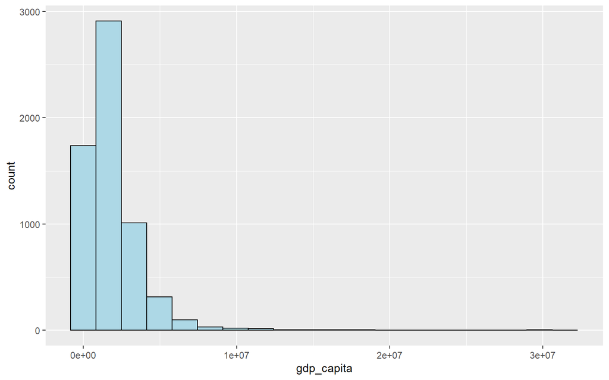

```r
ggplot(data = brazilGDPdist, aes(x = gdp_capita)) +
  geom_histogram(bins=20, color="black", fill="light blue")
```

## GDP per capita Choropleth Map

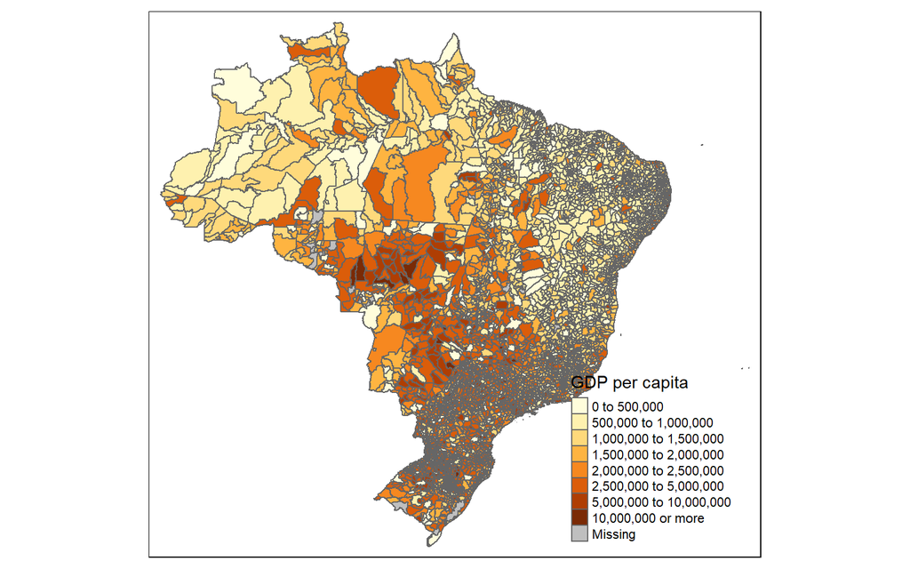

```r
tm_shape(brazilGDPdist)+
  tm_polygons("gdp_capita", title = "GDP per capita", breaks = c(0, 500000, 1000000, 1500000, 2000000, 2500000, 5000000, 10000000, Inf))
```

## Histogram of all variables

From the histograms, we observe that working_prop, edu_hdi and life_hdi seem to follow a normal distribution. For avg_tax, area, pop_density, planted_prop, company_psk, agropec_gvaprop, services_gvaprop and industry_gvaprop follow a right skewed distribution. The distribution of public_gvaprop is somewhat normal, with large values at both ends of the distribution. [View here](https://reginaooi.github.io/Brazil_Municipalities/Additional_Brazil_Plots.html)

```r
working_prop_h <- ggplot(data=brazilcities.sf, aes(x= working_prop)) +
  geom_histogram(bins=20, color="black", fill="light blue")

local_prop_h <- ggplot(data=brazilcities.sf, aes(x= local_prop)) +
  geom_histogram(bins=20, color="black", fill="light blue")

edu_hdi_h <- ggplot(data=brazilcities.sf, aes(x= edu_hdi)) +
  geom_histogram(bins=20, color="black", fill="light blue")

life_hdi_h <- ggplot(data=brazilcities.sf, aes(x= life_hdi)) +
  geom_histogram(bins=20, color="black", fill="light blue")

gni_hdi_h <- ggplot(data=brazilcities.sf, aes(x= gni_hdi)) +
  geom_histogram(bins=20, color="black", fill="light blue")

area_h <- ggplot(data=brazilcities.sf, aes(x= area)) +
  geom_histogram(bins=20, color="black", fill="light blue")

avg_tax_h <- ggplot(data=brazilcities.sf, aes(x= avg_tax)) +
  geom_histogram(bins=20, color="black", fill="light blue")

pop_density_h <- ggplot(data=brazilcities.sf, aes(x= pop_density)) +
  geom_histogram(bins=20, color="black", fill="light blue")

du_urban_prop_h <- ggplot(data=brazilcities.sf, aes(x= du_urban_prop)) +
  geom_histogram(bins=20, color="black", fill="light blue")

planted_prop_h <- ggplot(data=brazilcities.sf, aes(x= planted_prop)) +
  geom_histogram(bins=20, color="black", fill="light blue")

paytv_prop_h <- ggplot(data=brazilcities.sf, aes(x= paytv_prop)) +
  geom_histogram(bins=20, color="black", fill="light blue")

phones_prop_h <- ggplot(data=brazilcities.sf, aes(x= phones_prop)) +
  geom_histogram(bins=20, color="black", fill="light blue")

agropec_percap_h <- ggplot(data=brazilcities.sf, aes(x= agropec_percap)) +
  geom_histogram(bins=20, color="black", fill="light blue")

industry_percap_h <- ggplot(data=brazilcities.sf, aes(x= industry_percap)) +
  geom_histogram(bins=20, color="black", fill="light blue")

public_percap_h <- ggplot(data=brazilcities.sf, aes(x= public_percap)) +
  geom_histogram(bins=20, color="black", fill="light blue")

services_percap_h <- ggplot(data=brazilcities.sf, aes(x= services_percap)) +
  geom_histogram(bins=20, color="black", fill="light blue")

intermediate_adjacent_h <- ggplot(data=brazilcities.sf, aes(x= intermediate_adjacent)) +
  geom_bar(color="black", fill="light blue")

intermediate_remote_h <- ggplot(data=brazilcities.sf, aes(x= intermediate_remote)) +
  geom_bar(color="black", fill="light blue")

rural_remote_h <- ggplot(data=brazilcities.sf, aes(x= rural_remote)) +
  geom_bar(color="black", fill="light blue")

rural_adjacent_h <- ggplot(data=brazilcities.sf, aes(x= rural_adjacent)) +
  geom_bar(color="black", fill="light blue")

urban_h <- ggplot(data=brazilcities.sf, aes(x= urban)) +
  geom_bar(color="black", fill="light blue")
```

# Multi-Linear Regression Model

## Correlation between variables

We will be using brazilcities_GDP_rm to conduct the visualization. As this is purely for visualization purposes and removing 10 observations will not skew the outcome for over 5000 observations, we will temporarily remove the NA values. When we conduct the analysis later on using regression models, we will use the full data frame with NA values.

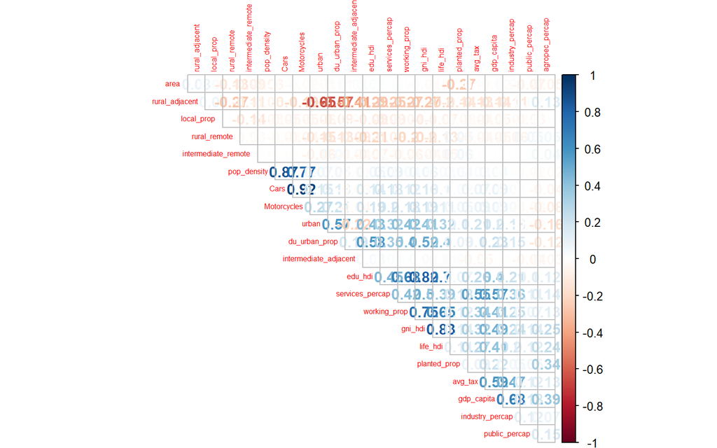

```r
corrplot(cor(brazilcities_GDP_rm[, 4:25]), diag = FALSE, order = "AOE",
         tl.pos = "td", tl.cex = 0.5, method = "number", type = "upper")
```

## Examining Linearity

By examining the relationship between GDP per capita and each independent variable, we can identify any need for data transformation to fit it to a linear model. [View here](https://reginaooi.github.io/Brazil_Municipalities/Additional_Brazil_Plots.html)

```r
# Proportion of adults at working age (working_prop)
l_working_prop <- ggplot(data = brazilcities.sf,
       aes(x = working_prop, y = gdp_capita)) +
  geom_point() +
  geom_smooth(method = lm)

# Proportion of local population (local_prop)
l_local_prop <- ggplot(data = brazilcities.sf,
       aes(x = local_prop, y = gdp_capita)) +
  geom_point() +
  geom_smooth(method = lm)

# Proportion of planted area (planted_prop)
l_planted_prop <- ggplot(data = brazilcities.sf,
       aes(x = planted_prop, y = gdp_capita)) +
  geom_point() +
  geom_smooth(method = lm)

# Amount of Tax per person (avg_tax)
l_avg_tax <- ggplot(data = brazilcities.sf,
       aes(x = avg_tax, y = gdp_capita)) +
  geom_point() +
  geom_smooth(method = lm)

# Gross Added Value of Industry proportion (industry_prop)
l_industry_percap <- ggplot(data = brazilcities.sf,
       aes(x = industry_percap, y = gdp_capita)) +
  geom_point() +
  geom_smooth(method = lm)

# Gross Added Value of Services proportion (services_prop)
l_services_percap <- ggplot(data = brazilcities.sf,
       aes(x = services_percap, y = gdp_capita)) +
  geom_point() +
  geom_smooth(method = lm)

# Gross Added Value of Public proportion (public_prop)
l_public_percap <- ggplot(data = brazilcities.sf,
       aes(x = public_percap, y = gdp_capita)) +
  geom_point() +
  geom_smooth(method = lm)

# Gross Added Value of Agropec proportion (agropec_prop)
l_agropec_percap <- ggplot(data = brazilcities.sf,
       aes(x = agropec_percap, y = gdp_capita)) +
  geom_point() +
  geom_smooth(method = lm)

# Area (area)
l_area <- ggplot(data = brazilcities.sf,
       aes(x = area, y = gdp_capita)) +
  geom_point() +
  geom_smooth(method = lm)

# Population Density (pop_density)
l_pop_density <- ggplot(data = brazilcities.sf,
       aes(x = pop_density, y = gdp_capita)) +
  geom_point() +
  geom_smooth(method = lm)
```

Looking at the scatterplot of population density, it is likely that it does not have a linear relationship with GDP per capita.

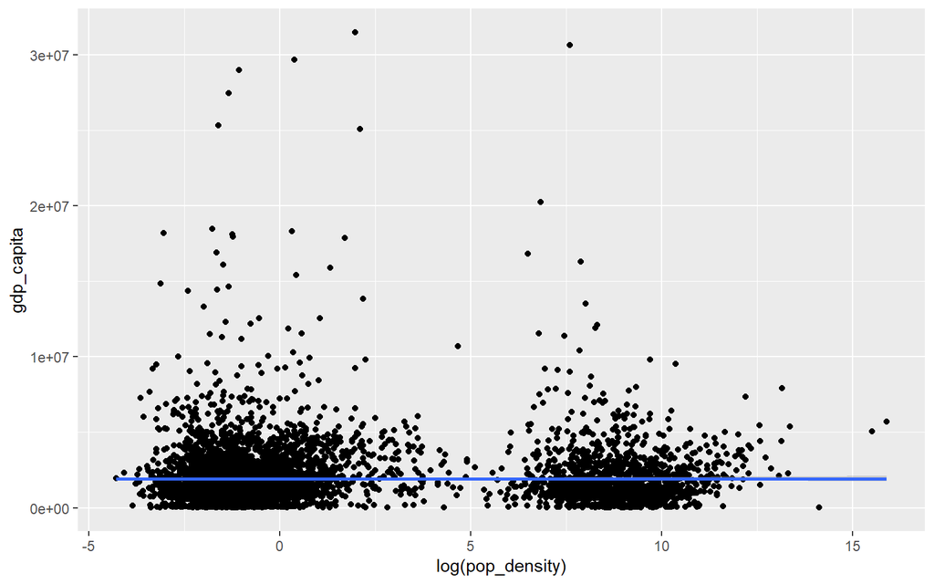

```r
ggplot(data = brazilcities.sf,
       aes(x = log(pop_density), y = gdp_capita)) +
  geom_point() +
  geom_smooth(method = lm)
```

## Multi-linear regression model

We will be using back brazilcities.sf, a data frame that does not omit the NA values.

**t-test hypotheses**

t-test Null Hypothesis: The coefficient estimate is zero. t-test Alternative Hypothesis: The coefficient estimate is not zero.

F-test Null Hypothesis: The variation explained by the model is due to chance. F-test Alternative Hypothesis: The variation explained by the model is not due to chance.

This test is conducted at 5% significance level. The alpha value is at 0.05.

### Without transformation

```r
brazilcities.mlr <- lm(formula = gdp_capita ~  area + working_prop + local_prop + life_hdi + industry_percap + services_percap + public_percap + agropec_percap + planted_prop + pop_density + avg_tax + intermediate_adjacent + intermediate_remote + rural_adjacent + rural_remote + urban, data = brazilcities.sf)
summary(brazilcities.mlr)
```

```
##
## Call:
## lm(formula = gdp_capita ~ area + working_prop + local_prop +
##     life_hdi + industry_percap + services_percap + public_percap +
##     agropec_percap + planted_prop + pop_density + avg_tax + intermediate_adjacent +
##     intermediate_remote + rural_adjacent + rural_remote + urban,
##     data = brazilcities.sf)
##
## Residuals:
##       Min        1Q    Median        3Q       Max
## -16315485   -190997      9767    240493  26005822
##
## Coefficients: (1 not defined because of singularities)
##                         Estimate Std. Error t value Pr(>|t|)
## (Intercept)           -1.457e+06  2.757e+06  -0.528 0.597348
## area                  -4.739e-02  5.967e-01  -0.079 0.936704
## working_prop           3.663e+06  6.529e+05   5.610 2.12e-08 ***
## local_prop            -2.806e+06  2.722e+06  -1.031 0.302621
## life_hdi               3.368e+06  4.485e+05   7.511 6.80e-14 ***
## industry_percap        9.650e+04  1.703e+03  56.665  < 2e-16 ***
## services_percap        5.884e+02  2.790e+01  21.091  < 2e-16 ***
## public_percap          2.487e+02  7.067e+01   3.519 0.000437 ***
## agropec_percap         8.315e+04  2.658e+03  31.279  < 2e-16 ***
## planted_prop           6.545e+00  1.556e+00   4.205 2.65e-05 ***
## pop_density            1.645e-01  1.118e-01   1.472 0.141212
## avg_tax                7.993e+04  4.326e+03  18.477  < 2e-16 ***
## intermediate_adjacent -1.134e+04  5.262e+04  -0.215 0.829395
## intermediate_remote   -1.301e+05  1.481e+05  -0.878 0.379786
## rural_adjacent        -7.012e+04  4.103e+04  -1.709 0.087504 .
## rural_remote           2.083e+03  7.401e+04   0.028 0.977549
## urban                         NA         NA      NA       NA
## ---
## Signif. codes:  0 '***' 0.001 '**' 0.01 '*' 0.05 '.' 0.1 ' ' 1
##
## Residual standard error: 1090000 on 5548 degrees of freedom
##   (8 observations deleted due to missingness)
## Multiple R-squared:  0.7096, Adjusted R-squared:  0.7088
## F-statistic: 903.8 on 15 and 5548 DF,  p-value: < 2.2e-16
```

**Analysis**

Looking at the adjusted R-square, this multiple linear regression model is able to account for 70.88% of the observations for the dependent variable, GDP per capita.

### With transformation

```r
brazilcities.mlr_log <- lm(formula = gdp_capita ~  area + working_prop + local_prop + life_hdi + industry_percap + services_percap + public_percap + agropec_percap + planted_prop + log(pop_density) + avg_tax + intermediate_adjacent + intermediate_remote + rural_adjacent + rural_remote + urban, data = brazilcities.sf)
summary(brazilcities.mlr_log)
```

```
##
## Call:
## lm(formula = gdp_capita ~ area + working_prop + local_prop +
##     life_hdi + industry_percap + services_percap + public_percap +
##     agropec_percap + planted_prop + log(pop_density) + avg_tax +
##     intermediate_adjacent + intermediate_remote + rural_adjacent +
##     rural_remote + urban, data = brazilcities.sf)
##
## Residuals:
##       Min        1Q    Median        3Q       Max
## -16389748   -188920      8400    241870  25921877
##
## Coefficients: (1 not defined because of singularities)
##                         Estimate Std. Error t value Pr(>|t|)
## (Intercept)           -1.098e+06  2.755e+06  -0.399 0.690088
## area                  -1.778e+00  7.545e-01  -2.356 0.018485 *
## working_prop           3.407e+06  6.561e+05   5.193 2.14e-07 ***
## local_prop            -2.809e+06  2.719e+06  -1.033 0.301625
## life_hdi               3.259e+06  4.490e+05   7.259 4.44e-13 ***
## industry_percap        9.653e+04  1.701e+03  56.742  < 2e-16 ***
## services_percap        5.915e+02  2.778e+01  21.292  < 2e-16 ***
## public_percap          2.210e+02  7.091e+01   3.116 0.001843 **
## agropec_percap         8.226e+04  2.664e+03  30.880  < 2e-16 ***
## planted_prop           8.979e+00  1.690e+00   5.312 1.13e-07 ***
## log(pop_density)      -1.829e+04  5.042e+03  -3.627 0.000289 ***
## avg_tax                7.977e+04  4.321e+03  18.461  < 2e-16 ***
## intermediate_adjacent -3.387e+04  5.285e+04  -0.641 0.521662
## intermediate_remote   -1.159e+05  1.480e+05  -0.783 0.433774
## rural_adjacent        -1.139e+05  4.260e+04  -2.674 0.007516 **
## rural_remote           1.678e+04  7.407e+04   0.227 0.820783
## urban                         NA         NA      NA       NA
## ---
## Signif. codes:  0 '***' 0.001 '**' 0.01 '*' 0.05 '.' 0.1 ' ' 1
##
## Residual standard error: 1089000 on 5548 degrees of freedom
##   (8 observations deleted due to missingness)
## Multiple R-squared:  0.7102, Adjusted R-squared:  0.7094
## F-statistic: 906.4 on 15 and 5548 DF,  p-value: < 2.2e-16
```

**Analysis**

Looking at the adjusted R-square, this multiple linear regression model is able to account for 70.94% of the observations for the dependent variable, GDP per capita. This model fits better compared to the previous model without log transformations.

We will only reject all the rural-urban binary variables with t-values that are not statistically significant, except for rural_adjacent. This may mean that whether an area is rural and adjacent affects the GDP per pcapita, compare to other areas.

We will retain the independent variables pop_density, working_prop, industry_percap, services_percap, public_percap, agropec_percap, avg_tax, rural_adjacent and planted_prop. These explanatory variables are good for accounting of the observations in GDP per capita.

### Revised Model

We will be using ols_regress from oslrr() to check for goodness of fit of the linear model. We will be using this instead of summary() as summary() is convenient for checking of statistical significance in t-values and ols_regress() has a model summary that makes it convenient for checking for goodness of fit.

```r
brazilcities.mlr1 <- lm(formula = gdp_capita ~   working_prop + industry_percap + services_percap + public_percap + agropec_percap + planted_prop + log(pop_density) + avg_tax + rural_adjacent, data = brazilcities.sf)
ols_regress(brazilcities.mlr1)
```

```
##                            Model Summary
## --------------------------------------------------------------------
## R                       0.841       RMSE                1095037.899
## R-Squared               0.707       Coef. Var                56.847
## Adj. R-Squared          0.706       MSE                1.199108e+12
## Pred R-Squared          0.701       MAE                  494721.524
## --------------------------------------------------------------------
##  RMSE: Root Mean Square Error
##  MSE: Mean Square Error
##  MAE: Mean Absolute Error
##
##                                     ANOVA
## -----------------------------------------------------------------------------
##                     Sum of
##                    Squares          DF     Mean Square       F          Sig.
## -----------------------------------------------------------------------------
## Regression    1.605817e+16           9    1.784241e+15    1487.974    0.0000
## Residual      6.659846e+15        5554    1.199108e+12
## Total         2.271802e+16        5563
## -----------------------------------------------------------------------------
##
##                                               Parameter Estimates
## ---------------------------------------------------------------------------------------------------------------
##            model            Beta    Std. Error    Std. Beta      t        Sig            lower           upper
## ---------------------------------------------------------------------------------------------------------------
##      (Intercept)    -3108491.823    336893.851                 -9.227    0.000    -3768935.566    -2448048.079
##     working_prop     6112193.850    531637.611        0.097    11.497    0.000     5069976.154     7154411.546
##  industry_percap       96443.518      1708.084        0.472    56.463    0.000       93095.005       99792.031
##  services_percap         618.921        27.479        0.211    22.523    0.000         565.051         672.790
##    public_percap         279.610        70.454        0.029     3.969    0.000         141.492         417.727
##   agropec_percap       86072.616      2557.360        0.272    33.657    0.000       81059.189       91086.043
##     planted_prop           8.366         1.692        0.044     4.944    0.000           5.049          11.683
## log(pop_density)      -11855.774      3927.599       -0.026    -3.019    0.003      -19555.406       -4156.143
##          avg_tax       79047.130      4329.771        0.171    18.257    0.000       70559.085       87535.174
##   rural_adjacent     -108905.492     33463.727       -0.027    -3.254    0.001     -174507.488      -43303.495
## ---------------------------------------------------------------------------------------------------------------
```

**Analysis**

Consistent with the results from the previous model, the adjusted R-square is at 0.706, which means that this multiple linear regression model is able to account for 70.6% of the observations for the dependent variable, GDP per capita.

The F-statistic is a large value of 1487.974, which leads us to reject the null hypothesis as a large F-statistic indicate that the t<sup>2</sup> statistic is large and significant. We conclude that the variation explained by the model is not due to chance.

**Checking for multicollinearity**

We will be checking the VIF values to detect whether there are redundant explanatory variables correlated with one another. If the VIF value is above 8, it shows signs of correlation. It the VIF value is above 10, this shows a strong sign of multicollinearity.

```r
ols_vif_tol(brazilcities.mlr1)
```

```
##          Variables Tolerance      VIF
## 1     working_prop 0.7414869 1.348641
## 2  industry_percap 0.7559960 1.322758
## 3  services_percap 0.6011851 1.663381
## 4    public_percap 0.9603753 1.041260
## 5   agropec_percap 0.8068888 1.239328
## 6     planted_prop 0.6661984 1.501054
## 7 log(pop_density) 0.6982667 1.432118
## 8          avg_tax 0.6034456 1.657150
## 9   rural_adjacent 0.7764864 1.287853
```

**Analysis**

As all the VIF values fall below 8, there is no sign of correlation. We can proceed to test the assumptions for this model.

## Testing assumptions for multi-linear regression model

We will not be conducting serial autocorrelation as we do not know the order which the GDP per capita information is collected for each municipality. Hence we will not be able to test for a time series effect on the residuals.

**Linearity Assumption**

While we conducted the EDA previously to identify any non-linear relationships between the dependent and independent variables, it is not sufficient for us to assume linearity between variables. We will be plotting the residuals against the fitted values to check for linearity.

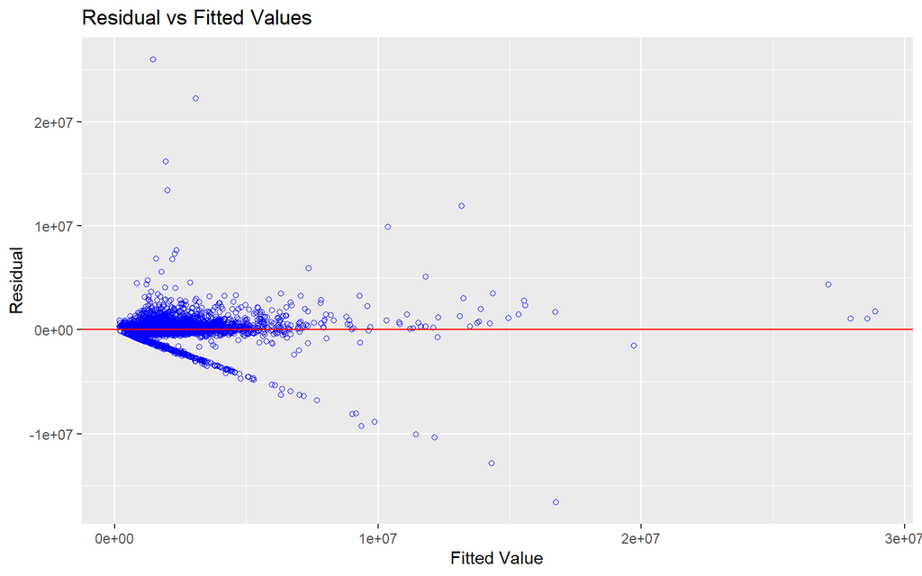

```r
ols_plot_resid_fit(brazilcities.mlr1)
```

**Analysis**

Most of the residuals bounce randomly around the 0 line. This suggests that the assumption that the relationship is linear is reasonable.

However, some residuals share a negative linear relationship with the fitted value. These values can cancel off other positive residual outliers.

The linearity assumption generally applies here.

**Normality Assumption**

We will be testing on the residuals, to check if its distribution resemble that of a normal distribution. If it follows a normal distribution, the expected mean error of the regression model is zero.

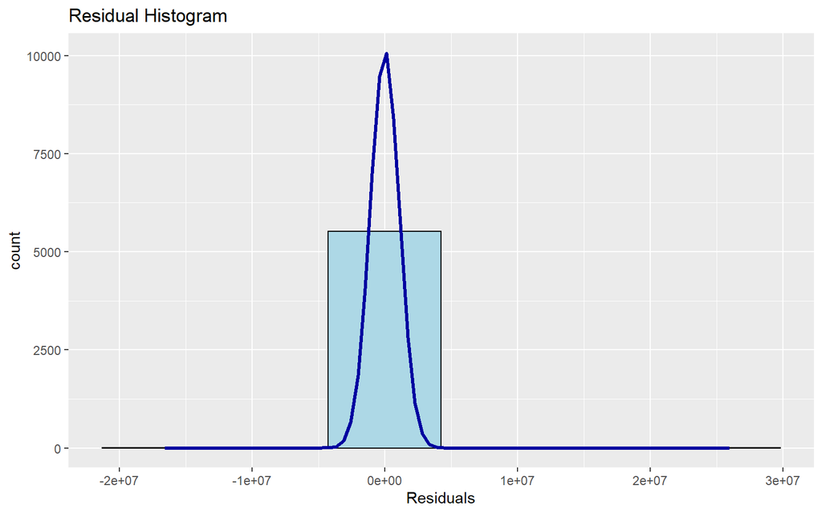

```r
ols_plot_resid_hist(brazilcities.mlr1)
```

**Analysis**

The plot shows that the residual of the multiple linear regression model resembles normal distribution.

**Absence of Heteroskedasticity Assumption**

We will be using the [Breusch Pagan test](https://www.rdocumentation.org/packages/olsrr/versions/0.5.3/topics/ols_test_breusch_pagan) from *olsrr* package.

This assumption should not be valid for a linear regression model, as the residuals should not vary with x. This means that the variance have to be constant in a linear regression model.

This is tested at 5% significance level.

```r
ols_test_breusch_pagan(brazilcities.mlr1)
```

```
##
##  Breusch Pagan Test for Heteroskedasticity
##  -----------------------------------------
##  Ho: the variance is constant
##  Ha: the variance is not constant
##
##                  Data
##  --------------------------------------
##  Response : gdp_capita
##  Variables: fitted values of gdp_capita
##
##         Test Summary
##  ----------------------------
##  DF            =    1
##  Chi2          =    7979.5884
##  Prob > Chi2   =    0.0000
```

**Testing for Spatial Autocorrelation**

We will export the residual from the multiple linear regression model and save it as a data frame.

```r
mlr.output <- as.data.frame(brazilcities.mlr1$residuals)
```

We will then join the newly created data frame with brazilcities.sf object. However, before doing joining, we will remove some variables to match the number of observations in the multiple linear regression model.

```r
brazilcities.sf.rm <- brazilcities.sf %>%
  dplyr::select(-edu_hdi, -life_hdi, -gni_hdi, -Cars, -Motorcycles, -intermediate_adjacent, - intermediate_remote, -local_prop, -rural_remote, -urban, -du_urban_prop, paytv_prop, phones_prop, -area) %>%
  mutate(`log(pop_density)` = log(`pop_density`)) %>%
  na.omit()
```

```r
brazilcities.res.sf <- cbind(brazilcities.sf.rm,
                        brazilcities.mlr1$residuals) %>%
rename(`MLR_RES` = `brazilcities.mlr1.residuals`)
```

We will convert brazilcities.res.sf simple feature object into a SpatialPointsDataFrame because spdep package can only process sp conformed spatial data objects.

```r
brazilcities.sp <- as_Spatial(brazilcities.res.sf)
brazilcities.sp
```

```
## class       : SpatialPointsDataFrame
## features    : 5564
## extent      : -72.9165, -0.04105083, -99.97771, 45.8544  (xmin, xmax, ymin, ymax)
## crs         : +proj=longlat +ellps=GRS80 +towgs84=0,0,0,0,0,0,0 +no_defs
## variables   : 17
## names       :            city, state, CAPITAL, gdp_capita, rural_adjacent,      working_prop,       pop_density,     planted_prop,           avg_tax,  agropec_percap,     industry_percap,     services_percap,       public_percap,           paytv_prop,         phones_prop, ...
## min values  : Abadia De Goiás,    AC,       0,       5507,              0, 0.471631205673759, 0.013845103366118,                0, -2.45169004329004,               0, 9.9322144488346e-05, 0.00570515746234596, 0.00291525872921222, 0.000634920634920635, 0.00131975867269985, ...
## max values  :          Zortéa,    TO,       1,   31463769,              1, 0.744760130414532,  7914072.61802237, 133744.979221599,  85.5122399150743, 121.05745471878,    254.919822229093,    10880.1267178012,    1497.68041120651,    0.966981132075472,    1.41405788541051, ...
```

## Distribution of Residuals

```r
brazilcities.res <- st_set_geometry(brazilcities.res.sf, NULL)
brazilcities.pol <- left_join(municipalities, brazilcities.res, by = c("name_mn" = "city"))
```

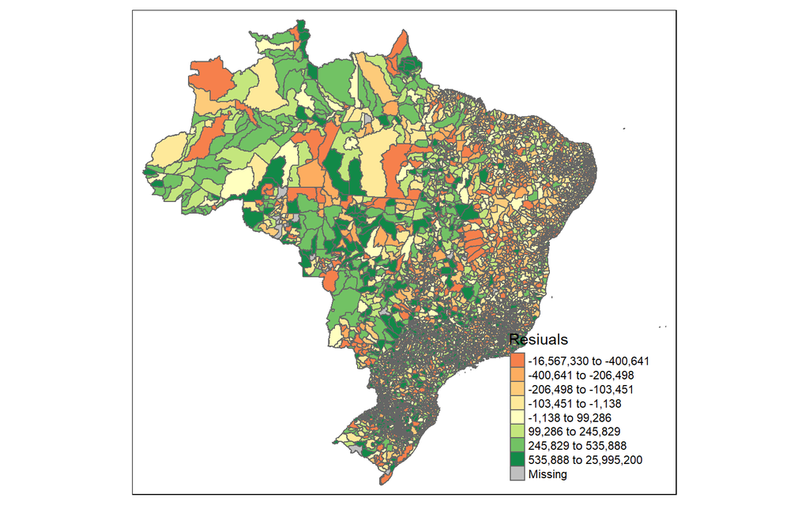

```r
tm_shape(municipalities) +
  tm_borders(alpha=0.5) +
tm_shape(brazilcities.pol)+
  tm_polygons(col = "MLR_RES", title="Resiuals", n=8, style= "quantile")
```

The spatial patterns indicate areas of over-prediction and under-prediction. Spatial autocorrelation may be present here.

# Multi-Linear Regression Model with Geographically Weighted Regression

Geographically weighted regression (GWR) is a spatial analysis technique that takes non-stationary variables into consideration (e.g., climate; demographic factors; physical environment characteristics). Since a municipality’s GDP per capita can be affected by adjacent municipalities, we have to take spatial variables into account.

## Fixed Bandwith Geographically Weighted Model

```r
# Computing the fixed bandwidth
bw.fixed <- bw.gwr(formula = gdp_capita ~   working_prop + industry_percap + services_percap + public_percap + agropec_percap + planted_prop + log(pop_density) + avg_tax + rural_adjacent, data = brazilcities.sp, approach="CV", kernel="gaussian", adaptive=FALSE, longlat=FALSE)
```

```
## Take a cup of tea and have a break, it will take a few minutes.
##           -----A kind suggestion from GWmodel development group
## Fixed bandwidth: 100.7687 CV score: 6.795954e+15
## Fixed bandwidth: 62.29096 CV score: 6.79647e+15
## Fixed bandwidth: 124.5493 CV score: 6.795951e+15
## Fixed bandwidth: 139.2465 CV score: 6.795961e+15
## Fixed bandwidth: 115.466 CV score: 6.795947e+15
## Fixed bandwidth: 109.8521 CV score: 6.795947e+15
## Fixed bandwidth: 118.9355 CV score: 6.795948e+15
## Fixed bandwidth: 113.3217 CV score: 6.795947e+15
## Fixed bandwidth: 111.9964 CV score: 6.795947e+15
## Fixed bandwidth: 114.1407 CV score: 6.795947e+15
## Fixed bandwidth: 112.8155 CV score: 6.795947e+15
## Fixed bandwidth: 112.5026 CV score: 6.795947e+15
## Fixed bandwidth: 113.0088 CV score: 6.795947e+15
## Fixed bandwidth: 112.696 CV score: 6.795947e+15
## Fixed bandwidth: 112.8893 CV score: 6.795947e+15
## Fixed bandwidth: 112.935 CV score: 6.795947e+15
## Fixed bandwidth: 112.8611 CV score: 6.795947e+15
## Fixed bandwidth: 112.9067 CV score: 6.795947e+15
## Fixed bandwidth: 112.8785 CV score: 6.795947e+15
## Fixed bandwidth: 112.896 CV score: 6.795947e+15
## Fixed bandwidth: 112.8852 CV score: 6.795947e+15
## Fixed bandwidth: 112.8919 CV score: 6.795947e+15
## Fixed bandwidth: 112.8877 CV score: 6.795947e+15
## Fixed bandwidth: 112.8868 CV score: 6.795947e+15
## Fixed bandwidth: 112.8883 CV score: 6.795947e+15
## Fixed bandwidth: 112.8874 CV score: 6.795947e+15
## Fixed bandwidth: 112.888 CV score: 6.795947e+15
## Fixed bandwidth: 112.8876 CV score: 6.795947e+15
## Fixed bandwidth: 112.8878 CV score: 6.795947e+15
## Fixed bandwidth: 112.8877 CV score: 6.795947e+15
## Fixed bandwidth: 112.8878 CV score: 6.795947e+15
```

```r
gwr.fixed <- gwr.basic(formula = gdp_capita ~   working_prop + industry_percap + services_percap + public_percap + agropec_percap + planted_prop + log(pop_density) + avg_tax + rural_adjacent, data = brazilcities.sp, bw=bw.fixed, kernel = 'gaussian', longlat = FALSE)

gwr.fixed
```

```
##    *                       Package   GWmodel                             *
##    Program starts at: 2021-03-07 19:10:15
##    Call:
##    gwr.basic(formula = gdp_capita ~ working_prop + industry_percap +
##     services_percap + public_percap + agropec_percap + planted_prop +
##     log(pop_density) + avg_tax + rural_adjacent, data = brazilcities.sp,
##     bw = bw.fixed, kernel = "gaussian", longlat = FALSE)
##
##    Dependent (y) variable:  gdp_capita
##    Independent variables:  working_prop industry_percap services_percap public_percap agropec_percap planted_prop pop_density avg_tax rural_adjacent
##    Number of data points: 5564
##    *                    Results of Global Regression                     *
##
##    Call:
##     lm(formula = formula, data = data)
##
##    Residuals:
##       Min        1Q    Median        3Q       Max
## -16567330   -206867     -2657    248819  25995200
##
##    Coefficients:
##                       Estimate Std. Error t value Pr(>|t|)
##    (Intercept)      -3.108e+06  3.369e+05  -9.227  < 2e-16 ***
##    working_prop      6.112e+06  5.316e+05  11.497  < 2e-16 ***
##    industry_percap   9.644e+04  1.708e+03  56.463  < 2e-16 ***
##    services_percap   6.189e+02  2.748e+01  22.523  < 2e-16 ***
##    public_percap     2.796e+02  7.045e+01   3.969 7.32e-05 ***
##    agropec_percap    8.607e+04  2.557e+03  33.657  < 2e-16 ***
##    planted_prop      8.366e+00  1.692e+00   4.944 7.87e-07 ***
##    log(pop_density) -1.186e+04  3.928e+03  -3.019  0.00255 **
##    avg_tax           7.905e+04  4.330e+03  18.257  < 2e-16 ***
##    rural_adjacent   -1.089e+05  3.346e+04  -3.254  0.00114 **
##
##    ---Significance stars
##    Signif. codes:  0 '***' 0.001 '**' 0.01 '*' 0.05 '.' 0.1 ' ' 1
##    Residual standard error: 1095000 on 5554 degrees of freedom
##    Multiple R-squared: 0.7068
##    Adjusted R-squared: 0.7064
##    F-statistic:  1488 on 9 and 5554 DF,  p-value: < 2.2e-16
##    ***Extra Diagnostic information
```

[output cut: 31 more lines]

```
##    planted_prop      8.6072e+00
##    log.pop_density. -1.1522e+04
##    avg_tax           7.9629e+04
##    rural_adjacent   -1.0153e+05
##    ************************Diagnostic information*************************
##    Number of data points: 5564
##    Effective number of parameters (2trace(S) - trace(S'S)): 10.92558
##    Effective degrees of freedom (n-2trace(S) + trace(S'S)): 5553.074
##    AICc (GWR book, Fotheringham, et al. 2002, p. 61, eq 2.33): 170548.2
##    AIC (GWR book, Fotheringham, et al. 2002,GWR p. 96, eq. 4.22): 170535.7
##    Residual sum of squares: 6.655026e+15
##    R-square value:  0.7070595
##    Adjusted R-square value:  0.7064831
##
##    Program stops at: 2021-03-07 19:10:31
```

## Visualising Output from the Geographically Weighted Regresson Model

The outputs of the GWR model include Local R2, Predicted values, Residuals and Coefficient Standard Error.

```r
brazilcities.sf.fixed <- st_as_sf(gwr.fixed$SDF) %>%
  st_transform(crs=4674)
gwr.fixed.output <- as.data.frame(gwr.fixed$SDF)
brazilcities.sf.fixed <- cbind(brazilcities.res.sf, as.matrix(gwr.fixed.output))
brazilcities.sf.fixed
```

```
## Simple feature collection with 5564 features and 55 fields
## geometry type:  POINT
## dimension:      XY
## bbox:           xmin: -72.9165 ymin: -99.97771 xmax: -0.04105083 ymax: 45.8544
## CRS:            EPSG:4674
## First 10 features:
##                   city state CAPITAL gdp_capita rural_adjacent
## 1      Abadia De Goiás    GO       0    2066457              0
## 2  Abadia Dos Dourados    MG       0     255917              1
## 3            Abadiânia    GO       0     156284              1
## 4               Abaeté    MG       0    1825042              0
## 5           Abaetetuba    PA       0     822236              0
## 6              Abaiara    CE       0     637041              1
## 7               Abaíra    BA       0      69827              0
## 8                Abaré    BA       0      62568              0
```

[output cut: 134 more lines]

```r
brazilcities.sf.fixed <- st_set_geometry(brazilcities.sf.fixed, NULL)
brazilcities.pol.gwr<- left_join(municipalities, brazilcities.sf.fixed, by = c("name_mn" = "city"))
```

Residuals are the differences between the fitted y values and the observed y values.

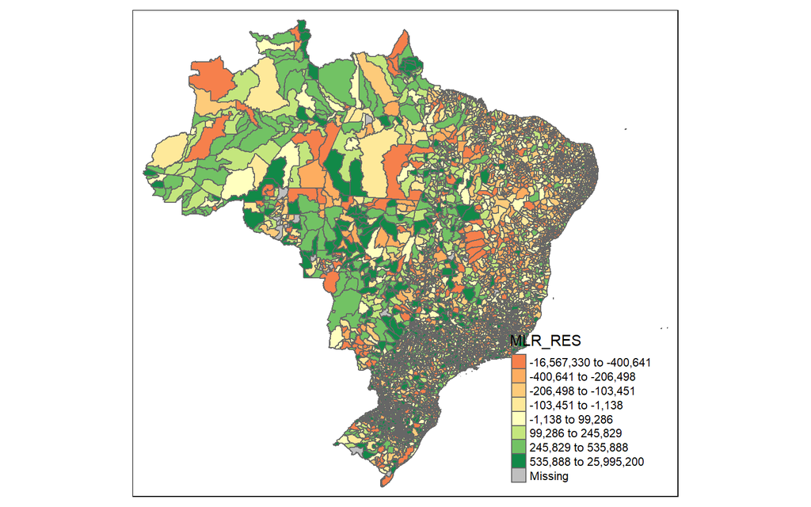

```r
tm_shape(municipalities) +
  tm_borders(alpha=0.5) +
tm_shape(brazilcities.pol.gwr)+
  tm_polygons(col = "MLR_RES", n=8, style= "quantile")
```

**Analysis**

There is a mix of positive and negative residual values throughout Brazil, with a large proportion of municipalities having residuals of large maginitude (both positive and negative). Larger areas tend to have large values of positive residuals (green) and smaller areas tend to have large values of negative residuals (orange). This means that the actual values of GDP per capita in large areas are more than the predicted values and the actual values of GDP per capita in small areas are less than the predicted values.

The fitted values differ largely from the observed values for most of the municipalities. Only a small proportion of municipalities have residuals in yellow, indicating small differences between the fitted and observed values of GDP per capita.